# Ggplot2 Principles

### Geometric layer [required]

The geometric layer in ggplot2 defines the type of plot to display by specifying the geometric objects (geoms) used to represent the data. Common geoms include `geom_point()` for scatter plots, `geom_line()` for line plots, and `geom_bar()` for bar charts. Each geom layer maps your data to shapes, lines, or other visual elements, forming the core of your plot. By combining multiple geoms in a single visualization, you can highlight different aspects of your data and build rich, layered plots tailored to your analytical needs.

Notice how we use the **‘+’** symbol to compose the geometric layer with the data/aesthetics layer.

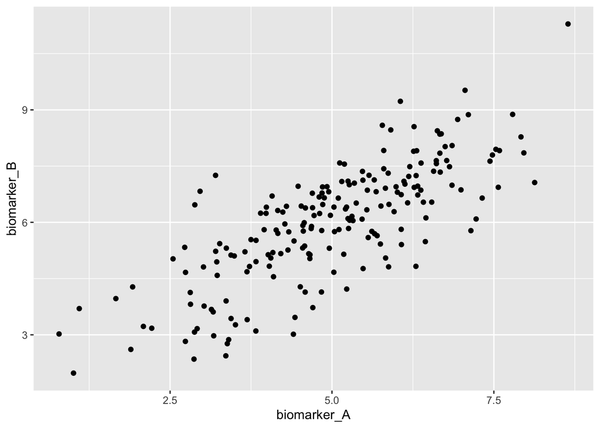

```r
# let's define the geomtric layer as points
ggplot(data = synthetic_data, aes(x = biomarker_A, y = biomarker_B)) +
  geom_point()
```

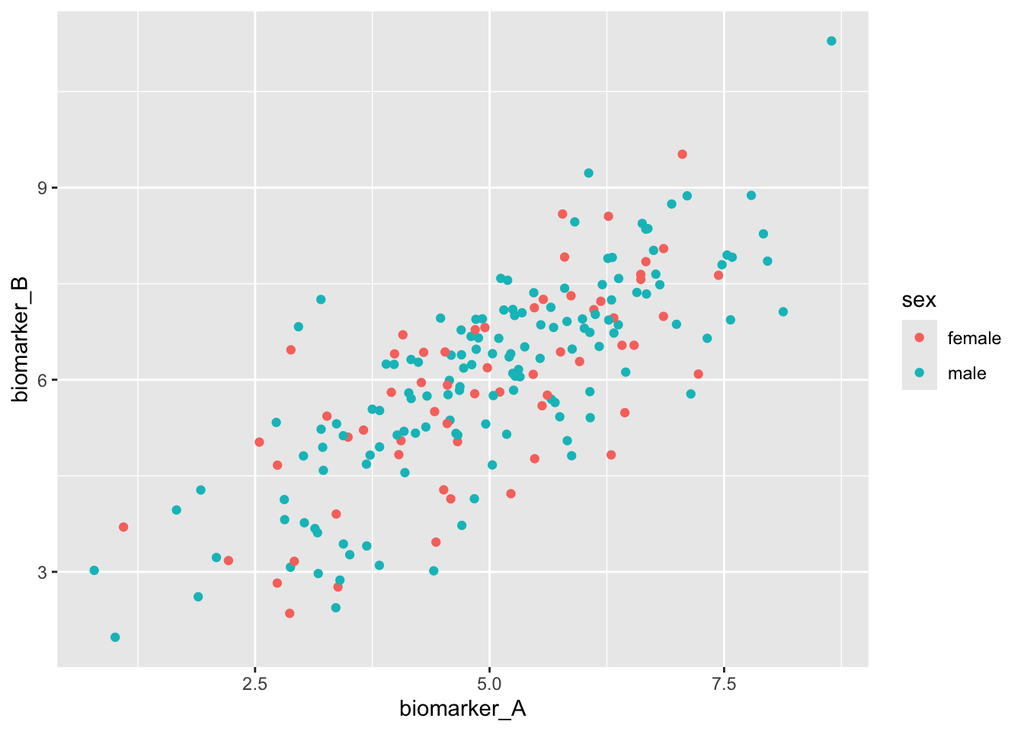

```r
# We add an aesthetic parameter with the definition of color mapped to the Sex variable
ggplot(data = synthetic_data, aes(x = biomarker_A, y = biomarker_B, color = sex)) +
  geom_point()
```

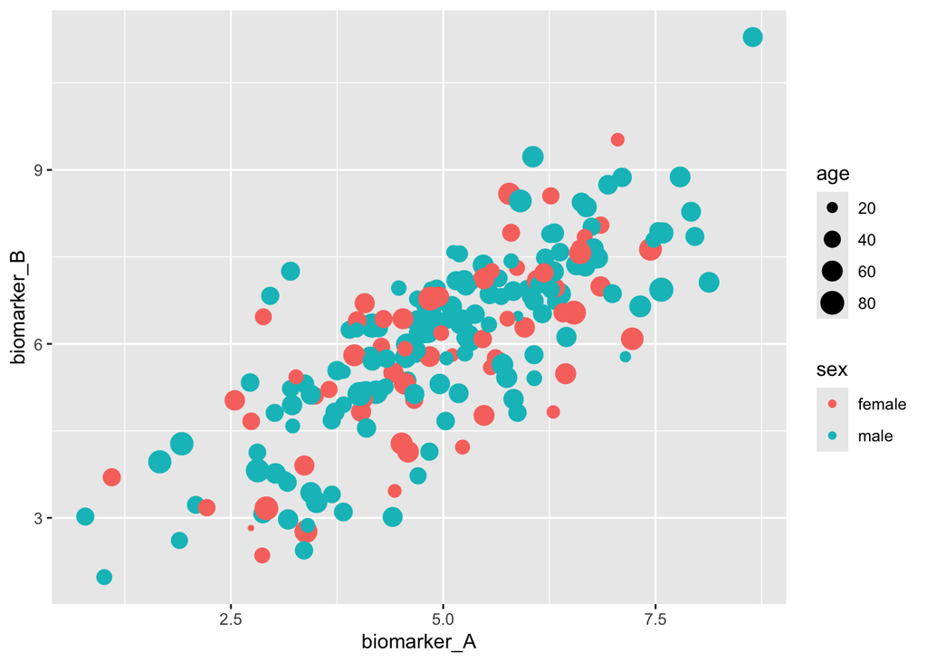

```r
# We add another aesthetic parameter with the size of the points mapped to the Age variable.
ggplot(data = synthetic_data, aes(x = biomarker_A, y = biomarker_B, color = sex, size = age)) +
  geom_point()
```

### Facet layer [optional]

Facets in ggplot2 allow you to split a dataset into subsets and create individual plots for each subset within a single visualization. This is done using the `facet_wrap` or `facet_grid` functions, which create small multiples based on one or more categorical variables. Facets are particularly useful for comparing trends, patterns, or relationships across groups.

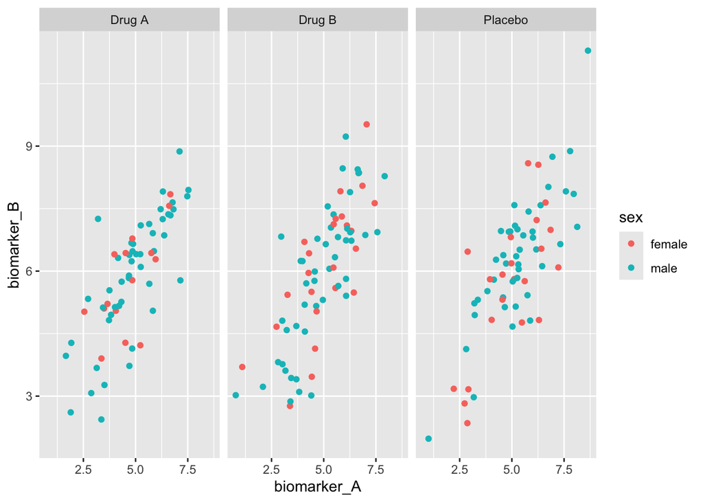

```r
ggplot(data = synthetic_data, aes(x = biomarker_A, y = biomarker_B, color = sex)) +
  geom_point() +
  facet_wrap(~ treatment)
```

### Statistics layer [optional]

The statistics layer in ggplot2 is used to compute and display derived data, such as summaries, transformations, or model fits, directly within a plot. This layer enhances visualizations by adding elements like trend lines, confidence intervals, or density estimates. For example, `geom_smooth()` can overlay a regression line on a scatter plot, while `stat_summary()` can calculate and display means or medians for grouped data. The statistics layer allows you to combine raw data with analytical insights, making your plots more informative and actionable.

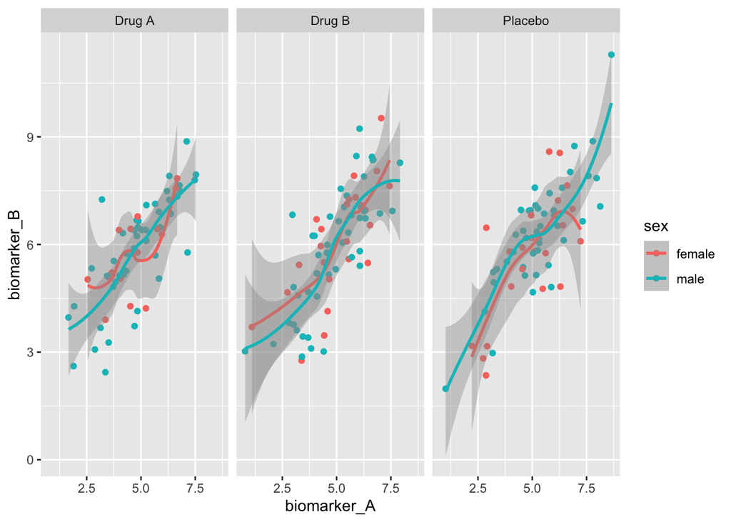

```r
# WE add a regression line to our plots
ggplot(data = synthetic_data, aes(x = biomarker_A, y = biomarker_B, color = sex)) +
  geom_point() +
  facet_wrap(~ treatment) +
  geom_smooth(method = "loess", se = TRUE)
```

### Coordinate layer [optional]

The coordinate layer in ggplot2 controls how data is mapped to the plot’s coordinate system, affecting the scale, aspect ratio, and layout of the visualization. It allows you to customize the view by using functions like `coord_cartesian()` for zooming in on specific data ranges, `coord_flip()` to swap the x- and y-axes, or `coord_polar()` for creating circular plots like pie charts. By modifying the coordinate layer, you can adjust the perspective of your plot to emphasize specific aspects of your data, improving clarity and interpretability.

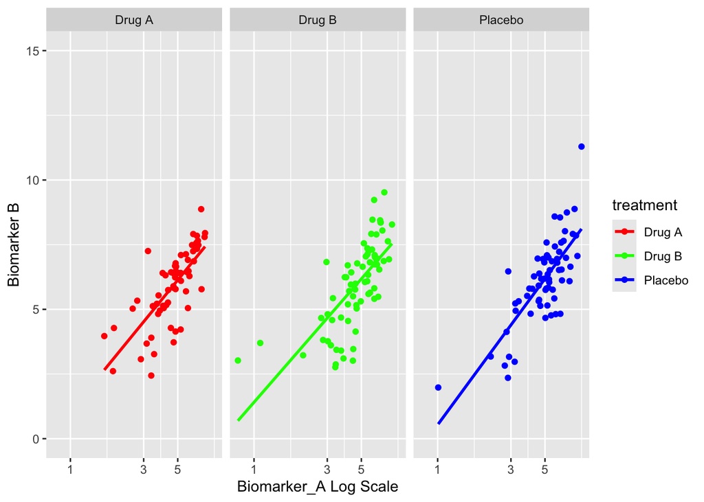

```r
ggplot(data = synthetic_data, aes(x = biomarker_A, y = biomarker_B, color = treatment)) +
  geom_point() +
  facet_wrap(~ treatment) +
  geom_smooth(method = "lm", se = FALSE) +
  # using a log10 scale for our X-axis
  scale_x_log10("Biomarker_A Log Scale") +
  # specifying the range of our Y axis to be displayed
  scale_y_continuous("Biomarker B", limits = c(0, 15)) +
  # specify the colors to be used
  scale_color_manual(values = c("Drug B"= "green","Drug A" = "red", "Placebo" = "blue"))
```

### Theme layer [optional]

The theme layer in **ggplot2** controls the non-data elements of a plot, such as axis labels, titles, legends, grid lines, and overall aesthetics. It allows you to customize the appearance of your plot to suit your needs, whether for publication, presentation, or exploratory analysis. Predefined themes like `theme_minimal()` or `theme_classic()` offer quick stylistic changes, while the `theme()` function provides fine-grained control over individual elements. By adjusting the theme layer, you can enhance the readability and visual appeal of your plots, ensuring they effectively communicate your data.

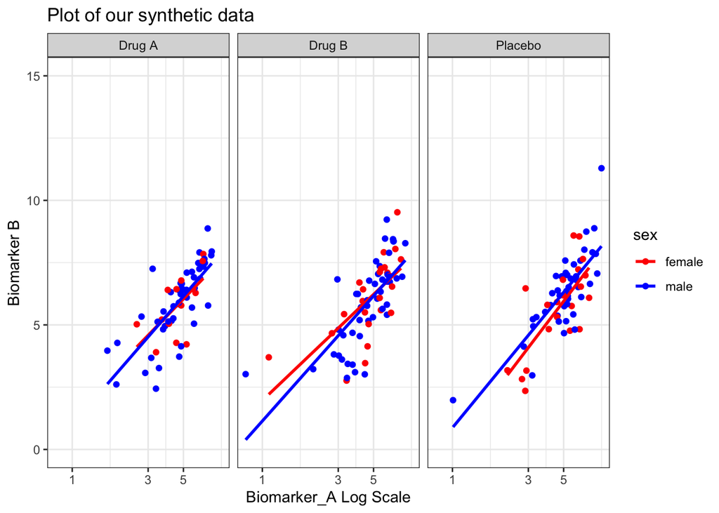

```r
ggplot(data = synthetic_data, aes(x = biomarker_A, y = biomarker_B, color = sex)) +
  geom_point() +
  facet_wrap(~ treatment) +
  geom_smooth(method = "lm", se = FALSE) +
  scale_x_log10("Biomarker_A Log Scale") +
  scale_y_continuous("Biomarker B", limits = c(0, 15)) +
  scale_color_manual(values = c("red", "blue")) +
  # let's use the predefined black-and-white theme
  # see also the predefined theme_minimal()
  theme_bw() +
  # add a title to our plot
  labs(title = "Plot of our synthetic data")
```

### **Conclusion: The Power of ggplot2 Layers**

The layered structure of ggplot2 is the foundation of its flexibility and power. Each layer—data, aesthetics, geoms, statistics, coordinates, facets, and themes—contributes a specific role in building a visualization. By composing these layers, you can create plots that are both highly customized and easy to interpret. This modular approach enables you to adapt your visualizations to different datasets, analysis needs, and presentation contexts, making ggplot2 an indispensable tool for data storytelling and scientific communication.